# Dynamic and Reproducible Report Using R

Mahbubul Majumder, PhD  
Sep 4, 2014

### How do we prepare report?

- Is that how you prepare data analysis report?

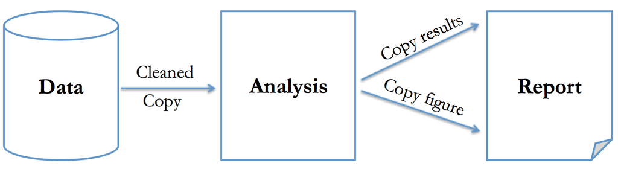

- What if we have to do it again and again
- What if the data changes or part of the data changes
- What if we can do everything from one place

### How can we do this from R?

- Wonderful R package knitr

```r
  install.packages("knitr")
  library("knitr")
```

- Install the package only once, but you have to include it every time you start R
- Its free

### Prepare the environment

- Install R
- Install LaTeX
- Install RStudio
- Configure RStudio by going to the menu

[figure not shown]

- Change Weave Rnw files using' to knitr

[figure not shown]

### Creating a Sweave (.Rnw) file

- Open a new R Sweave file to start
- The new file will start with a complete template
- You can compile the file from RStudio tool bar
- You can create HTML, or markdown documents for your blog or your personal web site

[figure not shown]

### R code chunk

- The syntax of embedding R codes is

```
<<>>=
..... your R codes here ....
@
```

- If you don't want to show your R code

```
<<echo=FALSE>>=
..... your R codes here ....
@
```

- You can embed inline R code using \Sexpr{}
- To view your document click on the compile pdf toolbar

### Including a table

- Use function `kable()` to display a table of data
- Please try `? kable` to learn more about the format, digits and row names
- Don't forget to put option `results='asis'`

```
<<eval=TRUE,  results='asis'>>=
library(knitr)
x <- head(mtcars)
kable(x,format = 'html', caption='Few records of mtcars')
@
```

Few records of mtcars

|  | mpg | cyl | disp | hp | drat | wt | qsec | vs | am | gear | carb |
| --- | --- | --- | --- | --- | --- | --- | --- | --- | --- | --- | --- |
| Mazda RX4 | 21.0 | 6 | 160 | 110 | 3.90 | 2.620 | 16.46 | 0 | 1 | 4 | 4 |
| Mazda RX4 Wag | 21.0 | 6 | 160 | 110 | 3.90 | 2.875 | 17.02 | 0 | 1 | 4 | 4 |
| Datsun 710 | 22.8 | 4 | 108 | 93 | 3.85 | 2.320 | 18.61 | 1 | 1 | 4 | 1 |
| Hornet 4 Drive | 21.4 | 6 | 258 | 110 | 3.08 | 3.215 | 19.44 | 1 | 0 | 3 | 1 |
| Hornet Sportabout | 18.7 | 8 | 360 | 175 | 3.15 | 3.440 | 17.02 | 0 | 0 | 3 | 2 |
| Valiant | 18.1 | 6 | 225 | 105 | 2.76 | 3.460 | 20.22 | 1 | 0 | 3 | 1 |

### Including a fancy table

- In latex \usepackage{booktabs}
- Use `kable(x,format = "latex", booktabs = TRUE)`

```
<<eval=TRUE,  results='asis'>>=
library(knitr)
x <- head(mtcars)
kable(x,format = 'latex', booktabs = TRUE)
@
```

- For more flexibility `install.packages("xtable")`

```
<<results ='asis'>>=
library(xtable)
x <- head(mtcars)
print(
  xtable(x,digits=2,
       caption ='has $\\alpha$ character', label = 'summary-data'), size='small',
  caption.placement = getOption('xtable.caption.placement', 'top')
  )
@
```

### Figures and references

```
<<my-plot, fig.cap='My caption', fig.width=4, fig.height=4, fig.align='center',fig.pos='hbtp',out.width='.45\\linewidth'>>=
plot(women)
@
```

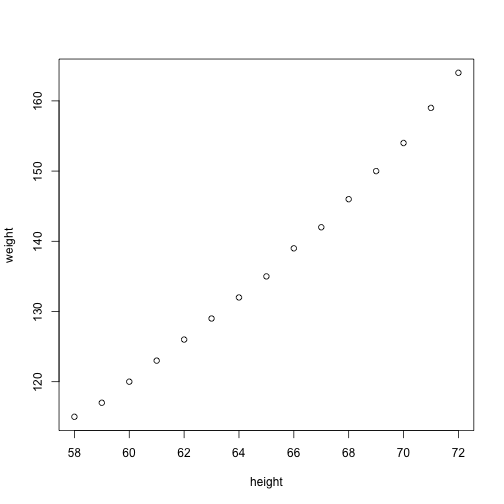

- Refer your figure from the text by saying `\ref{fig:my-plot}`

### Reading assignment and references

- knitr web site  
  http://yihui.name/knitr/
- [knitr book](http://www.amazon.com/dp/1482203537/ref=cm_sw_su_dp), Dynamic Documents with R and knitr by Yihui Xie. A book you will like to keep close to your hand.
- knitr showcase, examples from other users http://yihui.name/knitr/demo/showcase/
- For examples of reproducible documents checkout this website. You will find both pdf as well source (.Rnw) files. You may like to reproduce those pdf files. [http://www3.amherst.edu/~nhorton/sleuth/](http://www3.amherst.edu/%7Enhorton/sleuth/)